# Factores sociales y culturales que inciden en la probabilidad de los refugiados y migrantes venezolanos de conseguir un trabajo precario en Lima Metropolitana y Callao

Cynthia Villanueva Gaston

11/1/2021

# Base de datos y librerías

```r
library(rio)
library(DescTools)
library(rmdformats)
library(e1071)
```

```r
ENPOVE = "https://github.com/cvillanuevag/trabajo_enpove/raw/main/Base%20de%20datos%20ENPOVE.xlsx"
ENPOVE=import(ENPOVE)
```

## Introducción: (máximo 2 páginas)

En la actualidad, existen alrededor de 1,2 millones de migrantes y refugiados venezolanos en el Perú, según la data del Banco Mundial. El mayor flujo migratorio se confirma que ocurre en el año 2018, con más de la mitad de refugiados totales (635 000). Esto provocó distintas reacciones sociales, las cuales repercuten en las condiciones bajo las que esta población se adapta al contexto nacional. Estas condiciones son moldeadas a su vez, por las conductas generalizadas y psicosociales tan vívidos en el Perú, producto de procesos históricos y que como consecuencia ocasionan recurrentes divisiones y disputas en la población; estas son principalmente la misogínia y la discriminación étnica, racial y socioeconómica. Por tales motivos, la integración de la población venezolana ha sido ampliamente complicada, lo cual resulta preocupante ya que estamos hablando de un considerable número de personas, que cuentan con derechos y necesidades básicas a satisfacer. Ante tal situación, nuestro proyecto busca enfocarse en el factor laboral, ya que según datos oficiales, la mayoría de esta población debe recurrir a la precariedad laboral para poder subsistir. Esto es influenciado por distintos factores que analizaremos de forma cuantitativa, y que ayudarán a identificar las principales brechas a las que se enfrentan.

# Revisión de literatura

Mediante un repaso a la literatura existente en torno al tema migratorio, pudimos encontrar un concepto clave: precariedad laboral. Este fue definido por primera vez en 1974 por la OIT como la inestabilidad en el puesto de trabajo, ya sea por la inexistencia de contrato o por contratos por un tiempo determinado (Barattini, 2009). En adición a esto, Dasten Véjar (2017), uno de los académicos de la región que más se ha dedicado a investigar con respecto a precariedad, propone un concepto latinoamericana de empleo precario. Para él, este es un trabajo sin garantías laborales ni sociales que solo puede ser explicado a partir de la reestructuración productiva, la reforma de los sistemas salariales y las relaciones laborales. Estos elementos muestran sus efectos en la vulneración del trabajador y su desprotección en el espacio de trabajo. En relación a esto, el concepto más cercano al adoptado para el trabajo es el de Castillo, quien sugiere que el trabajo precario “corresponde a diversas formas de ocupaciones asalariadas y no asalariadas caracterizadas por la baja calidad, la inestabilidad en el empleo y la escasa seguridad en los ingresos o las remuneraciones” (2011, pp. 121)

Otros dos conceptos que deben de ser definidos son “inmigrantes” y “refugiados”, ya que muchas veces son confundidos como sinómidos uno del otro. El artículo de Yolanda Onghena resulta útil para explicar esta diferencia. Ella menciona que “la diferencia entre “refugiado” e “inmigrante” se basa en que el movimiento del primero sería un desplazamiento forzoso y en el caso del segundo, voluntario.” (2015, pp. 2) Cabe resaltar que es una situación de peligro - tanto al huir como la posibilidad de volver- la que marca la diferencia entre ambos conceptos.

El gobierno peruano cuenta con una política migratoria que intenta regular la situación laboral de los migrantes, según Lovón et. al (2021). Estos académicos, en su artículo La migración venezolana en el Perú: el discurso de la explotación laboral, mencionan que el Gobierno peruano estableció disposiciones para brindar un trabajo fijo en empresas privadas a los venezolanos que cuenten con un Permiso Temporal de Permanencia (PTP) o Acta de Permiso de Trabajo Extraordinaria y luego podrían solicitar un carné de extranjería. Además, la Superintendencia Nacional de Fiscalización Laboral (SUNAFIL) supervisa y fiscaliza centros de trabajos donde existen venezolanos contratados para asegurarse de que no reciban un menor pago que los peruanos al realizar una labor similar. Esta entidad es importante, ya que se encarga de garantizar el respeto al derecho de los trabajadores y, a su vez, promueve el cumplimieto de las normas laborales. En relación a esto, la SUNAFIL en 2019 dictaminó que no se debía de exigir la autorización previa del Ministerio de Trabajo a contratos de trabajadores venezolanos con PTP. Con respecto a la normativa internacional en torno al trabajo, Culqui (2015) menciona que el Perú se encuentra alineado a ellas y cuenta con normas que regulan la inmigración de los trabajadores. Sin embargo, estas normas “estas normas no necesariamente se ajustan a la normativa internacional que el Perú ha ratificado, debiendo ser revisadas y actualizadas, de modo que aseguren una protección adecuada de los derechos humanos de los migrantes, en este caso los derechos laborales’’. (pp. 6) A raíz de todo esto, Lovón et. at. (2021) concluyen que, pese a todo estos avances, la situación laboral de los venezolanos es precaria.

Por otro lado, en relación a la situación laboral de los inmigrantes venezolanos, Lovón et. al (2021) también afirman que de los 50000 venezolanos que conforman la fuerza laboral, solamente 4500 han sido contratados formalmente y figuran en la planilla electrónica del Ministerio de Trabajo y el resto se encuentra en el mercado informal. Este dato es relevante, ya que nos brinda información actualizada al ser uno de los papers más recientes. Es así como podemos concluir que el panorama con respecto a los inmigrantes venezolanos es preocupante, ya que el mercado informal es el que más asegura un trabajo precario y se encuentran en una situación de extrema vulnerabilidad.

# Objetivos

El presente trabajo se ha elaborado con la finalidad de identificar las variables que influyen en la posibilidad de que los inmigrantes venezolanos obtengan un trabajo precario. Nuestro objetivo principal es evidenciar y concientizar sobre las complicaciones que afronta la población migrante, frente a las obstrucciones que impone nuestra sociedad. Dentro de este objetivo encontramos distintas subcategorías, las cuales corresponden a factores que influyen o que se pueden evidenciar a partir del estudio de nuestro objetivo principal. En primer lugar, buscamos identificar cómo distintas características demográficas pueden influir, ya sea en conjunto o de forma individual, sobre las posibilidades de que un migrante labore de forma precaria. Entre estas características se pueden encontrar el nivel de estudios, nivel socioeconómico, etnia, género, orientación sexual, edad, entre otros. En segundo lugar, tenemos como objetivo concientizar acerca de cómo los problemas sociales peruanos, afectan también, e incluso en mayor medida, a personas en condición de migrantes. Estos son principalmente, racismo , clasismo y misoginia; históricamente la sociedad se ha visto jerarquizada y dividida por estas problemáticas, que a la vez determinan las jerarquías que también someten a las personas migrantes. Por último, buscamos evidenciar la fuerte problemática de informalidad en el país, la cual se ha visto agravada por las olas de inmigrantes, debido a la escasez de trabajo y a la falta de oportunidades que han tenido al llegar al país. Esta informalidad no afecta únicamente a personas migrantes sino también a los ciudadanos ya nacionalizados; sin embargo, se añade a las ya tantas dificultades que deben afrontar para poder instalarse en el Perú. Finalmente, hemos situado nuestra investigación únicamente en los distritos de Lima Metropolitana y Callao, puesto que poseen mayor cantidad de personas migrantes y también mayores índices de informalidad. En este sentido, nuestra pregunta de investigación será:

¿Qué factores sociales y culturales inciden en la probabilidad de los inmigrantes venezolanos de conseguir un trabajo precario en Lima Metropolitana y Callao ?

# Hipótesis

Como hipótesis sostenemos que, efectivamente, para la población venezolana existen mayores posibilidades de conseguir un trabajo precario. Esto podemos evidenciarlo por ejemplo en el aumento y concentración de la pobreza y extrema pobreza en este sector de la población, debido a que poseen menores herramientas para subsistir gracias a su condición de migrante. Ante esta pobreza, las personas suelen optar por cuales sean las oportunidades que se presenten, ya que caso contrario, no tendrían los medios para sobrevivir. En este sentido, sostenemos que dichas oportunidades están fuertemente limitadas debido a la condición de migrantes, principalmente, ya que genera desconfianza en los empleadores debido a los estigmas xenofóbicos en la sociedad, además de su situación migratoria. Además, existen estigmas transversales, referidos al género, raza, etnia, condición social, entre otros. Consideramos que, todos estos, en cierta medida contribuyen a que las posibilidades de conseguir un trabajo precario, aumenten, puesto que difícilmente lograrán ocupar un puesto de trabajo formal. Otro aspecto importante es que, como mencionamos anteriormente, al estar bajo fuertes condiciones de pobreza, aceptan trabajar por un pago menor al que debería ser, por lo tanto, tienden a ser explotados laboralmente, ya que las oportunidades que poseen son escasas.

# Población y muestra

El presente reporte estadístico se realizó utilizando una metodología cuantitativa, para esto se tomó en cuenta como unidad de análisis a los venezolanos encuestados. Se ha trabajado sobre una base de datos sobre 5844 venezolanos en Lima Metropolitana y Callao. La unidad de medida de dicho proyecto es la cantidad de personas venezolanas que cuentan con un trabajo precario, para así poder analizar qué variables recurrentes influyen en que se cuente con esta condición laboral.

# Operacionalización de las variables

Como variable dependiente se consideró el porcentaje de personas venezolanas que cuentan con un trabajo precario, es decir, que laboren sin los estándares mínimos dentro del sistema laboral. La data fue extraída del INEI, de la encuesta realizada en el año 2018. Para este trabajo se han considerado variables como sexo, condiciones demográficas, étnia, orientación sexual, entre otros. Hemos escogido estos datos porque consideramos que influyen en la variable dependiente.

# Técnicas utilizadas

# Análisis factorial exploratorio

La técnica de reducción elegida para el trabajo fue el análisis por factor común. El análisis factorial es una técnica estadística de interdependencia y de reducción de la dimensionalidad de los datos. Esta técnica tiene como propósito buscar el número mínimo de dimensiones capaces de explicar el máximo de información contenido en los datos. En este caso nos focalizamos en la varianza común. Aplicamos la técnica a nuestro trabajo. Regresión Lineal Múltiple

## Desarrollo

```r
names(ENPOVE)
```

```
##  [1] "NOMBDEPA" "VIVIENDA" "HOGAR"    "CODPERSO" "P204"     "P205_A"
##  [7] "P304"     "P408_1"   "P408_2"   "P408_3"   "P408_4"   "P408_5"
## [13] "P408_6"   "P501"     "P510"     "P512"     "P513"     "P604_1"
## [19] "P604_2"   "P604_3"   "P604_4"   "P604_5"   "P604_6"   "P604_7"
## [25] "P604_8"   "P604_9"   "P604_10"  "P604_11"  "P609"     "P611"
## [31] "P614_MON" "P614_ESP" "P615_MON" "P615_ESP" "P616_MON" "P616_ESP"
## [37] "P701"     "P315"     "P401"
```

```r
library(tidyverse)
enpove_subdata = ENPOVE %>%
  select(P205_A,P611, P614_MON, P614_ESP, P615_MON, P615_ESP, P616_MON, P616_ESP)
```

```r
enpove_subdata[,] = lapply(enpove_subdata[,], as.numeric)

str(enpove_subdata)
```

```
## 'data.frame':    5844 obs. of  8 variables:
##  $ P205_A  : num  33 32 30 31 25 27 28 23 25 61 ...
##  $ P611    : num  84 32 84 72 48 72 72 51 36 NA ...
##  $ P614_MON: num  50 60 50 600 410 600 600 300 200 NA ...
##  $ P614_ESP: num  0 0 0 0 0 0 0 0 28 NA ...
##  $ P615_MON: num  NA NA NA NA NA NA NA NA NA NA ...
##  $ P615_ESP: num  NA NA NA NA NA NA NA NA NA NA ...
##  $ P616_MON: num  0 0 0 0 0 0 0 200 0 NA ...
##  $ P616_ESP: num  0 0 0 0 0 0 0 84 0 NA ...
```

```r
enpove_subdata$P205_A[is.na(enpove_subdata$P205_A)] <- mean(enpove_subdata$P205_A,na.rm=TRUE)
enpove_subdata$P611[is.na(enpove_subdata$P611)] <- mean(enpove_subdata$P611,na.rm=TRUE)
enpove_subdata$P614_MON[is.na(enpove_subdata$P614_MON)] <- mean(enpove_subdata$P614_MON,na.rm=TRUE)
enpove_subdata$P614_ESP[is.na(enpove_subdata$P614_ESP)] <- mean(enpove_subdata$P614_ESP,na.rm=TRUE)
enpove_subdata$P615_MON[is.na(enpove_subdata$P615_MON)] <- mean(enpove_subdata$P615_MON,na.rm=TRUE)
enpove_subdata$P615_ESP[is.na(enpove_subdata$P615_ESP)] <- mean(enpove_subdata$P615_ESP,na.rm=TRUE)
enpove_subdata$P616_MON[is.na(enpove_subdata$P616_MON)] <- mean(enpove_subdata$P616_MON,na.rm=TRUE)
enpove_subdata$P616_ESP[is.na(enpove_subdata$P616_ESP)] <- mean(enpove_subdata$P616_ESP,na.rm=TRUE)
summary(enpove_subdata)
```

```
##      P205_A           P611           P614_MON         P614_ESP
##  Min.   : 0.00   Min.   :  0.00   Min.   :   5.0   Min.   :   0.00
##  1st Qu.:20.00   1st Qu.: 48.00   1st Qu.: 300.0   1st Qu.:   0.00
##  Median :27.00   Median : 52.85   Median : 508.8   Median :  19.51
##  Mean   :27.26   Mean   : 52.85   Mean   : 508.8   Mean   :  19.51
##  3rd Qu.:35.00   3rd Qu.: 66.00   3rd Qu.: 508.8   3rd Qu.:  19.51
##  Max.   :93.00   Max.   :141.00   Max.   :6000.0   Max.   :1700.00
##     P615_MON         P615_ESP         P616_MON          P616_ESP
##  Min.   : 140.0   Min.   :   0.0   Min.   :   0.00   Min.   :   0.0000
##  1st Qu.: 931.9   1st Qu.:  11.3   1st Qu.:   0.00   1st Qu.:   0.0000
##  Median : 931.9   Median :  11.3   Median :   0.00   Median :   0.0000
##  Mean   : 931.9   Mean   :  11.3   Mean   :  12.59   Mean   :   0.4922
##  3rd Qu.: 931.9   3rd Qu.:  11.3   3rd Qu.:   2.50   3rd Qu.:   0.0000
##  Max.   :8660.0   Max.   :1900.0   Max.   :1500.00   Max.   :1000.0000
```

```r
#install.packages("polycor")
library(polycor)
```

```r
library(psych)
poly_cor = polycor::hetcor(enpove_subdata)
poly_cor
```

```
##
## Two-Step Estimates
##
## Correlations/Type of Correlation:
##            P205_A     P611 P614_MON P614_ESP   P615_MON  P615_ESP P616_MON
## P205_A          1  Pearson  Pearson  Pearson    Pearson   Pearson  Pearson
## P611       0.1125        1  Pearson  Pearson    Pearson   Pearson  Pearson
## P614_MON  0.04445 0.004476        1  Pearson    Pearson   Pearson  Pearson
## P614_ESP  0.00416 0.008346   0.1518        1    Pearson   Pearson  Pearson
## P615_MON 0.000508  0.08015        0        0          1   Pearson  Pearson
## P615_ESP -0.01267  0.01472        0        0    0.05531         1  Pearson
## P616_MON    0.024   0.0914  0.03712  0.04936 -0.0002464 -0.006431        1
## P616_ESP 0.009485 0.005828  0.04622   0.2446 -7.316e-19 8.165e-21   0.2673
##          P616_ESP
## P205_A    Pearson
## P611      Pearson
## P614_MON  Pearson
## P614_ESP  Pearson
## P615_MON  Pearson
## P615_ESP  Pearson
## P616_MON  Pearson
## P616_ESP        1
##
## Standard Errors:
##           P205_A    P611 P614_MON P614_ESP P615_MON P615_ESP P616_MON
## P205_A
## P611     0.01292
## P614_MON 0.01306 0.01308
## P614_ESP 0.01308 0.01308  0.01278
## P615_MON 0.01308   0.013  0.01308  0.01308
## P615_ESP 0.01308 0.01308  0.01308  0.01308  0.01304
## P616_MON 0.01307 0.01297  0.01306  0.01305  0.01308  0.01308
## P616_ESP 0.01308 0.01308  0.01305   0.0123  0.01308  0.01308  0.01215
##
## n = 5844
##
## P-values for Tests of Bivariate Normality:
##          P205_A P611 P614_MON P614_ESP P615_MON P615_ESP P616_MON
## P205_A
## P611          0
## P614_MON      0    0
## P614_ESP      0    0        0
## P615_MON      0    0        0        0
## P615_ESP      0    0        0        0        0
## P616_MON      0    0        0        0        0        0
## P616_ESP      0    0        0        0        0        0        0
```

```r
corMatrix=poly_cor$correlations
corMatrix
```

```
##                 P205_A        P611    P614_MON    P614_ESP      P615_MON
## P205_A    1.0000000000 0.112460456 0.044453741 0.004159725  5.080464e-04
## P611      0.1124604559 1.000000000 0.004475589 0.008345703  8.014733e-02
## P614_MON  0.0444537413 0.004475589 1.000000000 0.151784857  0.000000e+00
## P614_ESP  0.0041597252 0.008345703 0.151784857 1.000000000  0.000000e+00
## P615_MON  0.0005080464 0.080147330 0.000000000 0.000000000  1.000000e+00
## P615_ESP -0.0126667653 0.014721095 0.000000000 0.000000000  5.531134e-02
## P616_MON  0.0240005730 0.091398304 0.037121786 0.049358491 -2.463598e-04
## P616_ESP  0.0094851400 0.005827607 0.046216830 0.244634179 -7.315632e-19
##               P615_ESP      P616_MON      P616_ESP
## P205_A   -1.266677e-02  0.0240005730  9.485140e-03
## P611      1.472110e-02  0.0913983037  5.827607e-03
## P614_MON  0.000000e+00  0.0371217858  4.621683e-02
## P614_ESP  0.000000e+00  0.0493584912  2.446342e-01
## P615_MON  5.531134e-02 -0.0002463598 -7.315632e-19
## P615_ESP  1.000000e+00 -0.0064308538  8.165377e-21
## P616_MON -6.430854e-03  1.0000000000  2.673146e-01
## P616_ESP  8.165377e-21  0.2673145912  1.000000e+00
```

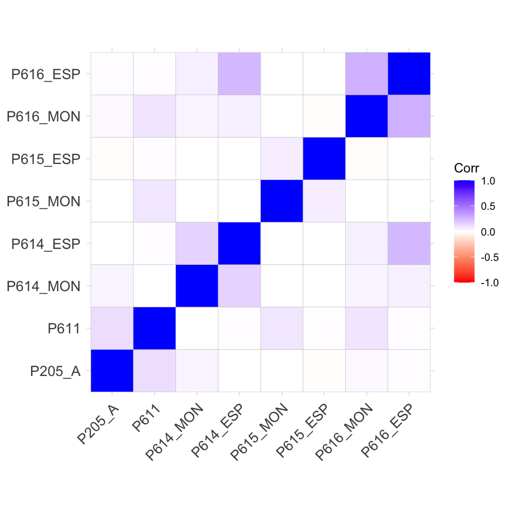

```r
#install.packages("ggcorrplot")
library(ggcorrplot)
ggcorrplot(corMatrix,colors = c("#ff0000", "white", "#0000ff"))
```

```r
library(psych)
psych::KMO(enpove_subdata[,1:8])
```

```
## Kaiser-Meyer-Olkin factor adequacy
## Call: psych::KMO(r = enpove_subdata[, 1:8])
## Overall MSA =  0.52
## MSA for each item =
##   P205_A     P611 P614_MON P614_ESP P615_MON P615_ESP P616_MON P616_ESP
##     0.51     0.50     0.54     0.52     0.50     0.51     0.51     0.51
```

```r
cortest.bartlett(corMatrix,n=nrow(enpove_subdata[,1:3]))$p.value>0.05
```

```
## [1] FALSE
```

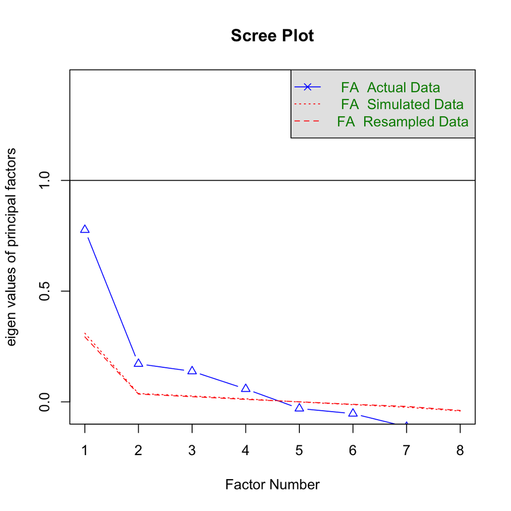

```
## Parallel analysis suggests that the number of factors =  4  and the number of components =  NA
```

```r
fa.parallel(enpove_subdata[,1:8], fm="pa", fa="fa", main = "Scree Plot")
```

```r
eigenf = eigen(cor(corMatrix, use="complete"))
eigenf$values
```

```
## [1] 1.908717e+00 1.401237e+00 1.315233e+00 1.057471e+00 9.208904e-01
## [6] 8.889635e-01 5.074877e-01 2.664535e-15
```

```r
itemsF_result <- fa(enpove_subdata[,3:8], cor = 'cor',
                     nfactors=4, rotate = 'varimax',fm='minres')
itemsF_result
```

```
## Factor Analysis using method =  minres
## Call: fa(r = enpove_subdata[, 3:8], nfactors = 4, rotate = "varimax",
##     fm = "minres", cor = "cor")
## Standardized loadings (pattern matrix) based upon correlation matrix
##           MR1   MR2  MR4  MR3    h2   u2 com
## P614_MON 0.00  0.04 0.33 0.00 0.109 0.89 1.0
## P614_ESP 0.29 -0.03 0.47 0.00 0.308 0.69 1.7
## P615_MON 0.00  0.00 0.00 0.10 0.011 0.99 1.0
## P615_ESP 0.00 -0.01 0.00 0.53 0.284 0.72 1.0
## P616_MON 0.17  0.65 0.04 0.00 0.450 0.55 1.1
## P616_ESP 0.66  0.23 0.12 0.00 0.510 0.49 1.3
##
##                        MR1  MR2  MR4  MR3
## SS loadings           0.55 0.48 0.34 0.29
## Proportion Var        0.09 0.08 0.06 0.05
## Cumulative Var        0.09 0.17 0.23 0.28
## Proportion Explained  0.33 0.29 0.21 0.18
## Cumulative Proportion 0.33 0.62 0.82 1.00
##
## Mean item complexity =  1.2
## Test of the hypothesis that 4 factors are sufficient.
##
## The degrees of freedom for the null model are  15  and the objective function was  0.16 with Chi Square of  954.67
## The degrees of freedom for the model are -3  and the objective function was  0
##
## The root mean square of the residuals (RMSR) is  0
## The df corrected root mean square of the residuals is  NA
##
## The harmonic number of observations is  5844 with the empirical chi square  0  with prob <  NA
## The total number of observations was  5844  with Likelihood Chi Square =  0  with prob <  NA
##
## Tucker Lewis Index of factoring reliability =  1.016
## Fit based upon off diagonal values = 1
## Measures of factor score adequacy
##                                                     MR1   MR2   MR4   MR3
## Correlation of (regression) scores with factors    0.68  0.66  0.54  0.54
## Multiple R square of scores with factors           0.46  0.43  0.29  0.29
## Minimum correlation of possible factor scores     -0.08 -0.14 -0.42 -0.42
```

```r
print(itemsF_result$loadings, cutoff = 0.5)
```

```
##
## Loadings:
##          MR1    MR2    MR4    MR3
## P614_MON
## P614_ESP
## P615_MON
## P615_ESP                       0.533
## P616_MON         0.648
## P616_ESP  0.664
##
##                  MR1   MR2   MR4   MR3
## SS loadings    0.554 0.477 0.344 0.294
## Proportion Var 0.092 0.080 0.057 0.049
## Cumulative Var 0.092 0.172 0.229 0.278
```

```r
sort(itemsF_result$communalities)
```

```
##   P615_MON   P614_MON   P615_ESP   P614_ESP   P616_MON   P616_ESP
## 0.01079192 0.10859994 0.28364835 0.30755767 0.44977096 0.50962218
```

```r
sort(itemsF_result$uniquenesses)
```

```
##  P616_ESP  P616_MON  P614_ESP  P615_ESP  P614_MON  P615_MON
## 0.4903768 0.5502286 0.6924393 0.7163515 0.8913953 0.9892113
```

```r
sort(itemsF_result$complexity)
```

```
## P615_MON P615_ESP P614_MON P616_MON P616_ESP P614_ESP
## 1.000039 1.000311 1.026799 1.140828 1.317654 1.684388
```

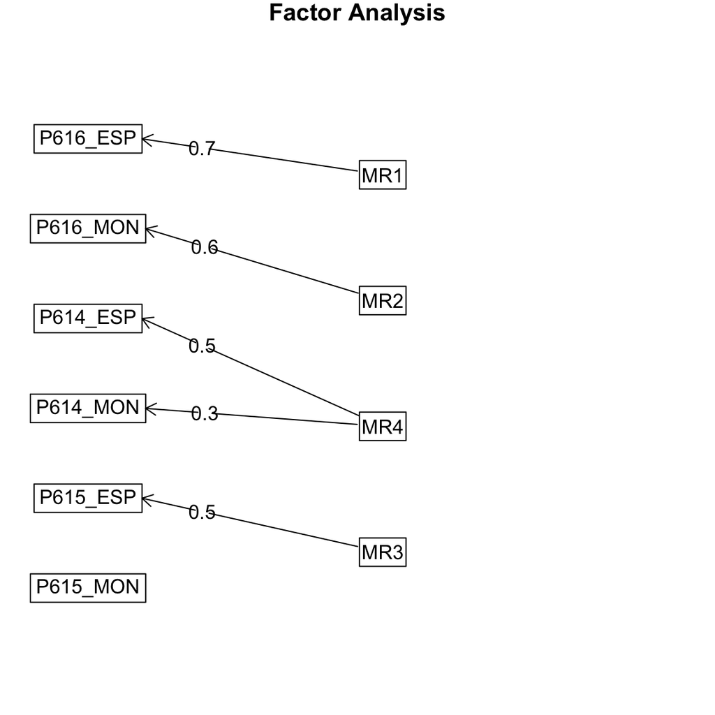

```r
fa.diagram(itemsF_result)
```

```r
data_factores = cbind(enpove_subdata, as.data.frame(itemsF_result$scores))
```

```r
library(BBmisc)
enpove_subdata$uno = normalize(data_factores$MR1,
                       method = "range",
                       margin=2, # by column
                       range = c(0, 100))

enpove_subdata$dos = normalize(data_factores$MR2,
                       method = "range",
                       margin=2, # by column
                       range = c(0, 100))

enpove_subdata$tres = normalize(data_factores$MR3,
                       method = "range",
                       margin=2, # by column
                       range = c(0, 100))

enpove_subdata$cuatro = normalize(data_factores$MR4,
                       method = "range",
                       margin=2, # by column
                       range = c(0, 100))
```

```r
modelo1 = lm(ENPOVE$P614_MON ~ enpove_subdata$uno + enpove_subdata$dos + enpove_subdata$tres + enpove_subdata$cuatro)
summary(modelo1)
```

```
##
## Call:
## lm(formula = ENPOVE$P614_MON ~ enpove_subdata$uno + enpove_subdata$dos +
##     enpove_subdata$tres + enpove_subdata$cuatro)
##
## Residuals:
##        Min         1Q     Median         3Q        Max
## -2.395e-08  2.900e-12  9.000e-12  1.250e-11  1.938e-10
##
## Coefficients:
##                         Estimate Std. Error    t value Pr(>|t|)
## (Intercept)           -6.564e+04  1.484e-09 -4.424e+13   <2e-16 ***
## enpove_subdata$uno    -2.151e+02  5.441e-12 -3.953e+13   <2e-16 ***
## enpove_subdata$dos     6.015e+01  1.887e-12  3.187e+13   <2e-16 ***
## enpove_subdata$tres    4.227e+04  9.518e-10  4.441e+13   <2e-16 ***
## enpove_subdata$cuatro  8.099e+01  1.472e-12  5.502e+13   <2e-16 ***
## ---
## Signif. codes:  0 '***' 0.001 '**' 0.01 '*' 0.05 '.' 0.1 ' ' 1
##
## Residual standard error: 4.276e-10 on 3140 degrees of freedom
##   (2699 observations deleted due to missingness)
## Multiple R-squared:      1,  Adjusted R-squared:      1
## F-statistic: 8.949e+26 on 4 and 3140 DF,  p-value: < 2.2e-16
```

Nuestro modelo segun la ganancia neta en monto